# Lab5

Sofia Ingersoll

2023-02-07

This week’s lab is a musical lab. You’ll be requesting data from the Spotify API and using it to build k-nearest neighbor and decision tree models.

In order to use the Spotify API you must have a Spotify account. If you don’t have one, sign up for a free one here: https://www.spotify.com/us/signup

Once you have an account, go to Spotify for developers (https://developer.spotify.com/) and log in. Click the green “Create a Client ID” button to fill out the form to create an app create an app so you can access the API.

On your developer dashboard page, click on the new app you just created. Go to Settings -> Basic Information and you will find your Client ID . Click “View client secret” to access your secondary Client ID. Scroll down to Redirect URIs and enter: http://localhost:1410/

You have two options for completing this lab.

**Option 1**: **Classify by users**. Build models that predict whether a given song will be in your collection vs. a partner in class. This requires that you were already a Spotify user so you have enough data to work with. You will download your data from the Spotify API and then exchange with another member of class.

**Option 2**: **Classify by genres**. Build models that predict which genre a song belongs to. This will use a pre-existing Spotify dataset available from Kaggle.com (https://www.kaggle.com/datasets/mrmorj/dataset-of-songs-in-spotify)

Client ID and Client Secret are required to create and access token that is required to interact with the API. You can set them as system values so we don’t have to do provide them each time.

**Option 1: Data Preparation**

You can use get_my_saved_tracks() to request all your liked tracks. It would be good if you had at least 150-200 liked tracks so the model has enough data to work with. If you don’t have enough liked tracks, you can instead use get_my_recently_played(), and in that case grab at least 500 recently played tracks if you can.

The Spotify API returns a dataframe of tracks and associated attributes. However, it will only return up to 50 (or 20) tracks at a time, so you will have to make multiple requests. Use a function to combine all your requests in one call.

Once you have your tracks, familiarize yourself with this initial dataframe. You’ll need to request some additional information for the analysis. If you give the API a list of track IDs using get_track_audio_features(), it will return an audio features dataframe of all the tracks and some attributes of them.

These track audio features are the predictors we are interested in, but this dataframe doesn’t have the actual names of the tracks. Append the ‘track.name’ column from your favorite tracks database.

Find a class mate whose data you would like to use. Add your partner’s data to your dataset. Create a new column that will contain the outcome variable that you will try to predict. This variable should contain two values that represent if the track came from your data set or your partner’s.

**Option 2: Data preparation**

Download the Spotify dataset from https://www.kaggle.com/datasets/mrmorj/dataset-of-songs-in-spotify

Inspect the data. Choose two genres you’d like to use for the classification task. Filter down the data to include only the tracks of that genre.

###Data Exploration (both options)

Let’s take a look at your data. Do some exploratory summary stats and visualization.

For example: What are the most danceable tracks in your dataset? What are some differences in the data between users (Option 1) or genres (Option 2)?

### **Modeling**

Create competing models that predict whether a track belongs to:

Option 1. you or your partner’s collection

**Option 2. genre 1 or genre 2**

You will eventually create four final candidate models:

1. k-nearest neighbor (Week 5)
2. decision tree (Week 5)
3. bagged tree (Week 6)
- bag_tree()
- Use the “times =” argument when setting the engine during model specification to specify the number of trees. The rule of thumb is that 50-500 trees is usually sufficient. The bottom of that range should be sufficient here.
4. random forest (Week 6)
- rand_forest()
- m_try() is the new hyperparameter of interest for this type of model. Make sure to include it in your tuning process

Go through the modeling process for each model:

Preprocessing. You can use the same recipe for all the models you create.

Resampling. Make sure to use appropriate resampling to select the best version created by each algorithm.

Tuning. Find the best values for each hyperparameter (within a reasonable range).

Compare the performance of the four final models you have created.

Use appropriate performance evaluation metric(s) for this classification task. A table would be a good way to display your comparison. Use at least one visualization illustrating your model results.

## Libraries

```r
#~~~~~~~~~~~~~~~~~~~~~~~~~~~~~~~~~~~~~~~~~~~~~~~~~~~~~~~~~~~~~~~~~~~~~~~~~~~~~~~
# ----                         System Set Up                                ----
#~~~~~~~~~~~~~~~~~~~~~~~~~~~~~~~~~~~~~~~~~~~~~~~~~~~~~~~~~~~~~~~~~~~~~~~~~~~~~~~
knitr::opts_chunk$set(echo = TRUE, message = FALSE, warning = FALSE)

library(here)         # easy file paths
library(tidyverse)    # data wrangling
library(tidymodels)   # modeling
library(xgboost)      # package for boosted trees
library(ranger)       # package for random forest non-default external package
library(patchwork)
library(tidymodels)
library(ranger)
library(xgboost)
library(rpart)
library(ipred)       # for fitting bagged decision trees
library(parsnip)
library(doParallel)  # for parallel backend to foreach
library(foreach)     # for parallel processing with for loops
library(caret)       # for general model fitting
library(vip)
library(baguette)
library(sjPlot)
library(kableExtra)
library(patchwork)

set.seed(99)          # set random seed
```

## Loading and Splitting Data

```r
#~~~~~~~~~~~~~~~~~~~~~~~~~~~~~~~~~~~~~~~~~~~~~~~~~~~~~~~~~~~~~~~~~~~~~~~~~~~~~~~
# ----                       Load & Clean Data                              ----
#~~~~~~~~~~~~~~~~~~~~~~~~~~~~~~~~~~~~~~~~~~~~~~~~~~~~~~~~~~~~~~~~~~~~~~~~~~~~~~~
# genre data set
kaggle_dat <- read_csv(here("data","genres_v2.csv"))

# table(kaggle_dat$genre)
# unique(kaggle_dat$genre)

# Removing uninformative columns and selecting
# techhouse and hardstyle as the two genres here and making case consistent

genre_dat <- kaggle_dat %>%
  select(-c(type, uri, track_href, analysis_url, `Unnamed: 0`, title, tempo, id, song_name)) %>%
  filter(genre == "techhouse"| genre == "hardstyle") %>%
  mutate(genre = as.factor(genre))

#~~~~~~~~~~~~~~~~~~~~~~~~~~~~~~~~~~~~~~~~~~~~~~~~~~~~~~~~~~~~~~~~~~~~~~~~~~~~~~~
# ----                         Split Data                                   ----
#~~~~~~~~~~~~~~~~~~~~~~~~~~~~~~~~~~~~~~~~~~~~~~~~~~~~~~~~~~~~~~~~~~~~~~~~~~~~~~~
# split the data
genre_split <- initial_split(genre_dat)

# traing data
genre_train <- training(genre_split)

# testing data
genre_test <- testing(genre_split)


#~~~~~~~~~~~~~~~~~~~~~~~~~~~~~~~~~~~~~~~~~~~~~~~~~~~~~~~~~~~~~~~~~~~~~~~~~~~~~~~
# ----                      Prep Data for Models                            ----
#~~~~~~~~~~~~~~~~~~~~~~~~~~~~~~~~~~~~~~~~~~~~~~~~~~~~~~~~~~~~~~~~~~~~~~~~~~~~~~~
# Pre process the data
genre_rec <- recipe(genre ~ .,
                    data = genre_train) %>%
  step_dummy(all_nominal_predictors(),
             one_hot = TRUE) %>%
  step_normalize(all_numeric())
```

# K Nearest Neighbor Model

Matching based on characteristics

```r
#~~~~~~~~~~~~~~~~~~~~~~~~~~~~~~~~~~~~~~~~~~~~~~~~~~~~~~~~~~~~~~~~~~~~~~~~~~~~~~~
# ----                            Tuning KNN                                ----
#~~~~~~~~~~~~~~~~~~~~~~~~~~~~~~~~~~~~~~~~~~~~~~~~~~~~~~~~~~~~~~~~~~~~~~~~~~~~~~~
# Define our KNN model with tuning, not expecting a number just that main argu = tune
knn_spec_tune <- nearest_neighbor(neighbors = tune()) %>%
  set_mode("classification") %>%
  set_engine("kknn")

#~~~~~~~~~~~~~~~~~~~~~~~~~~~~~~~~~~~~~~~~~~~~~~~~~~~~~~~~~~~~~~~~~~~~~~~~~~~~~~~
# ----                           Workflow                                   ----
#~~~~~~~~~~~~~~~~~~~~~~~~~~~~~~~~~~~~~~~~~~~~~~~~~~~~~~~~~~~~~~~~~~~~~~~~~~~~~~~
# Define a new workflow
wf_knn_tune <- workflow() %>%
  add_model(knn_spec_tune) %>%
  add_recipe(genre_rec)

#~~~~~~~~~~~~~~~~~~~~~~~~~~~~~~~~~~~~~~~~~~~~~~~~~~~~~~~~~~~~~~~~~~~~~~~~~~~~~~~
# ----                        Cross Validation                              ----
#~~~~~~~~~~~~~~~~~~~~~~~~~~~~~~~~~~~~~~~~~~~~~~~~~~~~~~~~~~~~~~~~~~~~~~~~~~~~~~~
#set up k-fold cv. This can be used for all the algorithms
genre_cv <- genre_train %>%
  vfold_cv(v = 10)

# Fit the workflow on our predefined folds and a grid of hyperparameters
fit_knn_cv <- wf_knn_tune %>%
  tune_grid(
    genre_cv,
    #running model 60 times 5 folds x 12 neighbors
    grid = data.frame(neighbors = c(1,5,seq(10,100,10)))
  )

# Check the performance, ran the mdoel 5 times and measured accuracy and roc_auc
fit_knn_cv %>%
  collect_metrics()
```

```
## # A tibble: 24 × 7
##    neighbors .metric  .estimator  mean     n  std_err .config
##        <dbl> <chr>    <chr>      <dbl> <int>    <dbl> <chr>
##  1         1 accuracy binary     0.951    10 0.00286  Preprocessor1_Model01
##  2         1 roc_auc  binary     0.951    10 0.00302  Preprocessor1_Model01
##  3         5 accuracy binary     0.956    10 0.00255  Preprocessor1_Model02
##  4         5 roc_auc  binary     0.984    10 0.00180  Preprocessor1_Model02
##  5        10 accuracy binary     0.956    10 0.00301  Preprocessor1_Model03
##  6        10 roc_auc  binary     0.990    10 0.00127  Preprocessor1_Model03
##  7        20 accuracy binary     0.956    10 0.00311  Preprocessor1_Model04
##  8        20 roc_auc  binary     0.991    10 0.000678 Preprocessor1_Model04
##  9        30 accuracy binary     0.955    10 0.00251  Preprocessor1_Model05
## 10        30 roc_auc  binary     0.992    10 0.000816 Preprocessor1_Model05
## # ℹ 14 more rows
```

```r
#~~~~~~~~~~~~~~~~~~~~~~~~~~~~~~~~~~~~~~~~~~~~~~~~~~~~~~~~~~~~~~~~~~~~~~~~~~~~~~~
# ----                         Finalize Workflow                            ----
#~~~~~~~~~~~~~~~~~~~~~~~~~~~~~~~~~~~~~~~~~~~~~~~~~~~~~~~~~~~~~~~~~~~~~~~~~~~~~~~
# The final workflow for our KNN model. Finalize_workflow takes a workflow and a set of parameters.  In this case, that set is just the best value of k
final_wf <- wf_knn_tune %>%
  finalize_workflow(select_best(fit_knn_cv, metric = "accuracy"))

# Check out the final workflow object.  Choosing accuracy for interpretability in this simple binary context, mine found that 20 neighbors was most accurate
#final_wf
#~~~~~~~~~~~~~~~~~~~~~~~~~~~~~~~~~~~~~~~~~~~~~~~~~~~~~~~~~~~~~~~~~~~~~~~~~~~~~~~
# ----                             Fit Model                                ----
#~~~~~~~~~~~~~~~~~~~~~~~~~~~~~~~~~~~~~~~~~~~~~~~~~~~~~~~~~~~~~~~~~~~~~~~~~~~~~~~

# Fitting our final workflow
final_fit <- final_wf %>%
  fit(data = genre_train)
# Examine the final workflow
#final_fit

# get prediction for test
test_predict_knn <- predict(final_fit, genre_test) %>%
  # bind to testing column
  bind_cols(genre_test) %>%
  mutate(genre = as.factor(genre))

# get testing prediction probabilities
test_predict_knn2 <- predict(final_fit,
                             genre_test,
                             type = "prob") %>%
  # bind to testing column
  bind_cols(genre_test) %>%
  mutate(genre = as.factor(genre))
#~~~~~~~~~~~~~~~~~~~~~~~~~~~~~~~~~~~~~~~~~~~~~~~~~~~~~~~~~~~~~~~~~~~~~~~~~~~~~~~
# ----                          Evaluate Model                              ----
#~~~~~~~~~~~~~~~~~~~~~~~~~~~~~~~~~~~~~~~~~~~~~~~~~~~~~~~~~~~~~~~~~~~~~~~~~~~~~~~
# get accuracy of testing prediction
genre_knn_pred <- final_fit %>%
  predict(new_data = genre_test)


# get accuracy of testing prediction
knn_accuracy <- accuracy(test_predict_knn, truth = genre, estimate = .pred_class)


#~~~~~~~~~~~~~~~~~~~~~~~~~~~~~~~~~~~~~~~~~~~~~~~~~~~~~~~~~~~~~~~~~~~~~~~~~~~~~~~
# ----                        Visual of Fit Model                          ----
#~~~~~~~~~~~~~~~~~~~~~~~~~~~~~~~~~~~~~~~~~~~~~~~~~~~~~~~~~~~~~~~~~~~~~~~~~~~~~~~

# Write over 'final_fit' with this last_fit() approach
final_fit <- final_wf %>%
  last_fit(genre_split)
# Collect metrics on the test data!
final_fit %>%  collect_metrics()
```

```
## # A tibble: 2 × 4
##   .metric  .estimator .estimate .config
##   <chr>    <chr>          <dbl> <chr>
## 1 accuracy binary         0.963 Preprocessor1_Model1
## 2 roc_auc  binary         0.987 Preprocessor1_Model1
```

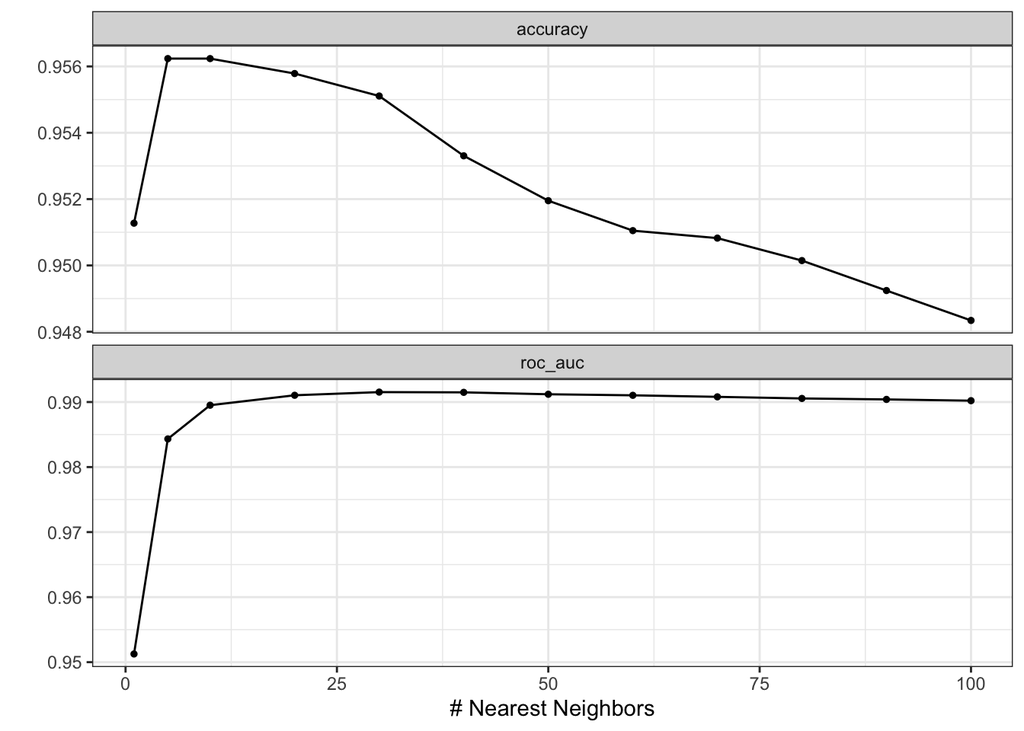

```r
autoplot(fit_knn_cv) +
  theme_bw()
```

# Decision Tree

Parallel trees with tuning parameters to optimize model fitting.

```r
#~~~~~~~~~~~~~~~~~~~~~~~~~~~~~~~~~~~~~~~~~~~~~~~~~~~~~~~~~~~~~~~~~~~~~~~~~~~~~~~
# ----                       Tuning Decision Tree                           ----
#~~~~~~~~~~~~~~~~~~~~~~~~~~~~~~~~~~~~~~~~~~~~~~~~~~~~~~~~~~~~~~~~~~~~~~~~~~~~~~~
# new spec, tell the model that we are tuning hyperparams
tree_spec_tune <- decision_tree(
  cost_complexity = tune(),
  tree_depth = tune(),
  min_n = tune()
) %>%
  set_engine('rpart') %>%
  set_mode('classification')

# info about the possible range of this hyperparameter valuea
# 5 x 5 x 5 grid of the parameters for cross validation
tree_grid <- grid_regular(cost_complexity(),
                          tree_depth(),
                          min_n(),
                          levels = 5)

#~~~~~~~~~~~~~~~~~~~~~~~~~~~~~~~~~~~~~~~~~~~~~~~~~~~~~~~~~~~~~~~~~~~~~~~~~~~~~~~
# ----                           Workflow                                   ----
#~~~~~~~~~~~~~~~~~~~~~~~~~~~~~~~~~~~~~~~~~~~~~~~~~~~~~~~~~~~~~~~~~~~~~~~~~~~~~~~
# create workflow
wf_tree_tune <- workflow() %>%
  add_recipe(genre_rec) %>%
  add_model(tree_spec_tune)

#~~~~~~~~~~~~~~~~~~~~~~~~~~~~~~~~~~~~~~~~~~~~~~~~~~~~~~~~~~~~~~~~~~~~~~~~~~~~~~~
# ----                        Cross Validation                              ----
#~~~~~~~~~~~~~~~~~~~~~~~~~~~~~~~~~~~~~~~~~~~~~~~~~~~~~~~~~~~~~~~~~~~~~~~~~~~~~~~

#set up k-fold cv. This can be used for all the algorithms
genre_cv <- genre_train %>%
  vfold_cv(v = 10)

#~~~~~~~~~~~~~~~~~~~~~~~~~~~~~~~~~~~~~~~~~~~~~~~~~~~~~~~~~~~~~~~~~~~~~~~~~~~~~~~
# ----                         Parallel Trees                               ----
#~~~~~~~~~~~~~~~~~~~~~~~~~~~~~~~~~~~~~~~~~~~~~~~~~~~~~~~~~~~~~~~~~~~~~~~~~~~~~~~
# in parallel, create a set of decision trees
doParallel::registerDoParallel()

system.time(
  tree_rs <- tune_grid(
    wf_tree_tune,
    resamples = genre_cv,
    grid = tree_grid,
    metrics = metric_set(accuracy)
  )
)
```

```
##    user  system elapsed
##  66.944   0.698  13.632
```

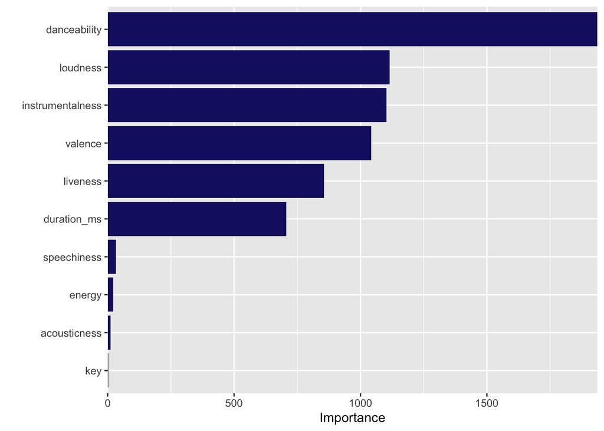

```r
#tree_rs

#~~~~~~~~~~~~~~~~~~~~~~~~~~~~~~~~~~~~~~~~~~~~~~~~~~~~~~~~~~~~~~~~~~~~~~~~~~~~~~~
# ----                         Finalize Workflow                            ----
#~~~~~~~~~~~~~~~~~~~~~~~~~~~~~~~~~~~~~~~~~~~~~~~~~~~~~~~~~~~~~~~~~~~~~~~~~~~~~~~
# finalize workflow using the best tree and tuning
final_tree <- finalize_workflow(wf_tree_tune,
                                select_best(tree_rs))

#~~~~~~~~~~~~~~~~~~~~~~~~~~~~~~~~~~~~~~~~~~~~~~~~~~~~~~~~~~~~~~~~~~~~~~~~~~~~~~~
# ----                             Fit Model                                ----
#~~~~~~~~~~~~~~~~~~~~~~~~~~~~~~~~~~~~~~~~~~~~~~~~~~~~~~~~~~~~~~~~~~~~~~~~~~~~~~~
#similar functions here.
final_tree_fit <- fit(final_tree,
                      data = genre_train)

# get prediction for test
test_predict_tree <- predict(final_tree_fit, genre_test) %>%
  # bind to testing column
  bind_cols(genre_test) %>%
  mutate(genre = as.factor(genre))

# get testing prediction probabilities
test_predict_tree2 <- predict(final_tree_fit,
                              genre_test,
                              type = "prob") %>%
  # bind to testing column
  bind_cols(genre_test) %>%
  mutate(genre = as.factor(genre))
#~~~~~~~~~~~~~~~~~~~~~~~~~~~~~~~~~~~~~~~~~~~~~~~~~~~~~~~~~~~~~~~~~~~~~~~~~~~~~~~
# ----                          Evaluate Model                              ----
#~~~~~~~~~~~~~~~~~~~~~~~~~~~~~~~~~~~~~~~~~~~~~~~~~~~~~~~~~~~~~~~~~~~~~~~~~~~~~~~
# get accuracy of testing prediction
tree_accuracy <- accuracy(test_predict_tree, truth = genre, estimate = .pred_class)

#tree_accuracy

#~~~~~~~~~~~~~~~~~~~~~~~~~~~~~~~~~~~~~~~~~~~~~~~~~~~~~~~~~~~~~~~~~~~~~~~~~~~~~~~
# ----                        Visual of Fit Model                          ----
#~~~~~~~~~~~~~~~~~~~~~~~~~~~~~~~~~~~~~~~~~~~~~~~~~~~~~~~~~~~~~~~~~~~~~~~~~~~~~~~
# Visualize fit model
final_tree_fit %>%
  vip(geom = 'col',
      aesthetics = list(fill = 'midnightblue'),
      alpha = 0.8) +
  scale_y_continuous(expand = c(0,0))
```

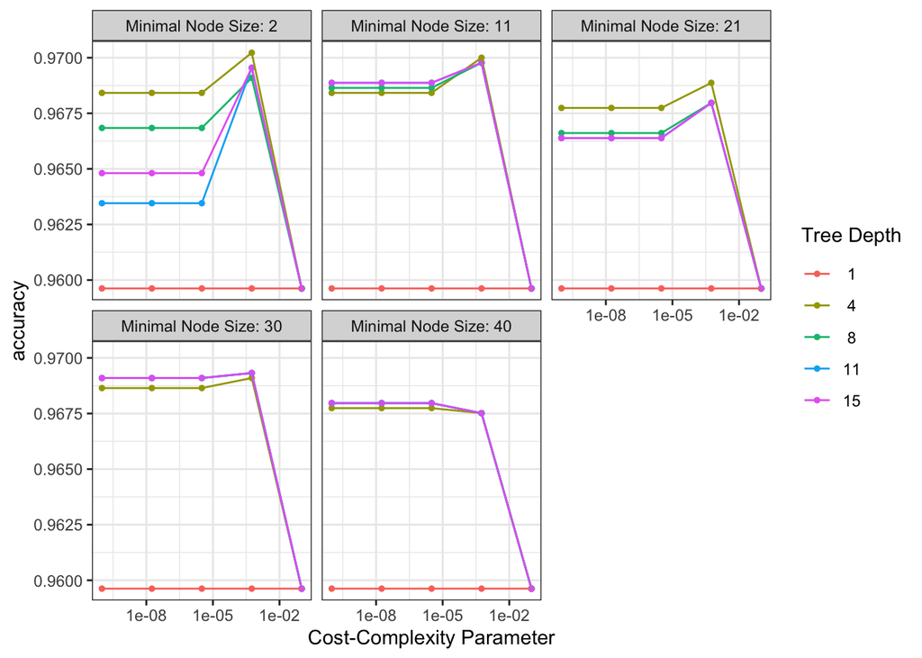

```r
#~~~~~~~~~~~~~~~~~~~~~~~~~~~~~~~~~~~~~~~~~~~~~~~~~~~~~~~~~~~~~~~~~~~~~~~~~~~~~~~
# ----                    Visualize Parallel Trees                          ----
#~~~~~~~~~~~~~~~~~~~~~~~~~~~~~~~~~~~~~~~~~~~~~~~~~~~~~~~~~~~~~~~~~~~~~~~~~~~~~~~
# visualize our parallel trees model
autoplot(tree_rs) +
  theme_bw()
```

# Bagged Tree

All covariates are considered

bag_tree

```r
#~~~~~~~~~~~~~~~~~~~~~~~~~~~~~~~~~~~~~~~~~~~~~~~~~~~~~~~~~~~~~~~~~~~~~~~~~~~~~~~
# ----                      Tuning Bagged Tree                              ----
#~~~~~~~~~~~~~~~~~~~~~~~~~~~~~~~~~~~~~~~~~~~~~~~~~~~~~~~~~~~~~~~~~~~~~~~~~~~~~~~
# train bagged model
# new spec, tell the model that we are tuning hyperparams
bagged_spec_tune <- bag_tree(
  cost_complexity = tune(),
  tree_depth = tune(),
  min_n = tune()
) %>%
  set_engine('rpart', times = 50) %>%
  set_mode('classification')

# info about the possible range of this hyperparameter values
# 5 x 5 x 5 grid of the parameters for cross validation
bagged_grid <- grid_regular(cost_complexity(),
                            tree_depth(),
                            min_n(),
                            levels = 5)

#~~~~~~~~~~~~~~~~~~~~~~~~~~~~~~~~~~~~~~~~~~~~~~~~~~~~~~~~~~~~~~~~~~~~~~~~~~~~~~~
# ----                           Workflow                                   ----
#~~~~~~~~~~~~~~~~~~~~~~~~~~~~~~~~~~~~~~~~~~~~~~~~~~~~~~~~~~~~~~~~~~~~~~~~~~~~~~~
wf_bagged_tune <- workflow() %>%
  add_recipe(genre_rec) %>%
  add_model(bagged_spec_tune)


##~~~~~~~~~~~~~~~~~~~~~~~~~~~~~~~~~~~~~~~~~~~~~~~~~~~~~~~~~~~~~~~~~~~~~~~~~~~~~~~
# ----                        Cross Validation                              ----
#~~~~~~~~~~~~~~~~~~~~~~~~~~~~~~~~~~~~~~~~~~~~~~~~~~~~~~~~~~~~~~~~~~~~~~~~~~~~~~~

#set up k-fold cv. This can be used for all the algorithms
genre_cv <- genre_train %>%
  vfold_cv(v = 10)

#~~~~~~~~~~~~~~~~~~~~~~~~~~~~~~~~~~~~~~~~~~~~~~~~~~~~~~~~~~~~~~~~~~~~~~~~~~~~~~~
# ----                         Parallel Bags                              ----
#~~~~~~~~~~~~~~~~~~~~~~~~~~~~~~~~~~~~~~~~~~~~~~~~~~~~~~~~~~~~~~~~~~~~~~~~~~~~~~~
# in parallel, create a set of decision trees
doParallel::registerDoParallel()

system.time(
  bagged_rs <- tune_grid(
    wf_bagged_tune,
    resamples = genre_cv,
    grid = bagged_grid,
    metrics = metric_set(accuracy)
  )
)
```

```
##    user  system elapsed
## 997.830   5.140 200.003
```

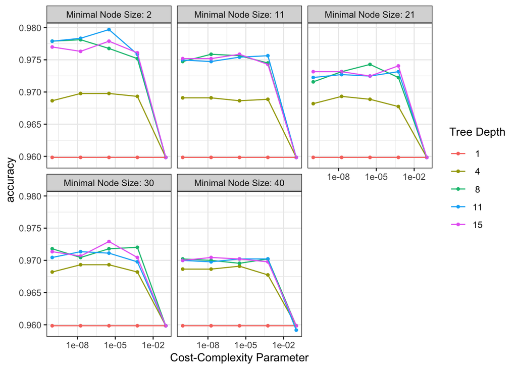

```r
#tree_rs
#~~~~~~~~~~~~~~~~~~~~~~~~~~~~~~~~~~~~~~~~~~~~~~~~~~~~~~~~~~~~~~~~~~~~~~~~~~~~~~~
# ----                         Finalize Workflow                            ----
#~~~~~~~~~~~~~~~~~~~~~~~~~~~~~~~~~~~~~~~~~~~~~~~~~~~~~~~~~~~~~~~~~~~~~~~~~~~~~~~
# finalize workflow using the best tree and tuning
final_bagged <- finalize_workflow(wf_bagged_tune,
                                  select_best(bagged_rs))

#~~~~~~~~~~~~~~~~~~~~~~~~~~~~~~~~~~~~~~~~~~~~~~~~~~~~~~~~~~~~~~~~~~~~~~~~~~~~~~~
# ----                             Fit Model                                ----
#~~~~~~~~~~~~~~~~~~~~~~~~~~~~~~~~~~~~~~~~~~~~~~~~~~~~~~~~~~~~~~~~~~~~~~~~~~~~~~~
#similar functions here.
final_bagged_fit <- fit(final_bagged,
                        data = genre_train)

# get prediction for test
test_predict_bagged <- predict(final_bagged_fit, genre_test) %>%
  # bind to testing column
  bind_cols(genre_test) %>%
  mutate(genre = as.factor(genre))

# get testing prediction probabilities
test_predict_bagged2 <- predict(final_bagged_fit,
                                genre_test,
                                type = "prob") %>%
  # bind to testing column
  bind_cols(genre_test) %>%
  mutate(genre = as.factor(genre))
#~~~~~~~~~~~~~~~~~~~~~~~~~~~~~~~~~~~~~~~~~~~~~~~~~~~~~~~~~~~~~~~~~~~~~~~~~~~~~~~
# ----                          Evaluate Model                              ----
#~~~~~~~~~~~~~~~~~~~~~~~~~~~~~~~~~~~~~~~~~~~~~~~~~~~~~~~~~~~~~~~~~~~~~~~~~~~~~~~
# get accuracy of testing prediction
bagged_accuracy <- accuracy(test_predict_bagged, truth = genre, estimate = .pred_class)


#~~~~~~~~~~~~~~~~~~~~~~~~~~~~~~~~~~~~~~~~~~~~~~~~~~~~~~~~~~~~~~~~~~~~~~~~~~~~~~~
# ----                    Visualize Parallel Trees                          ----
#~~~~~~~~~~~~~~~~~~~~~~~~~~~~~~~~~~~~~~~~~~~~~~~~~~~~~~~~~~~~~~~~~~~~~~~~~~~~~~~
# visualize our parallel bagged trees model
autoplot(bagged_rs) +
  theme_bw()
```

# Random Forest

A random subset of covariates are considered

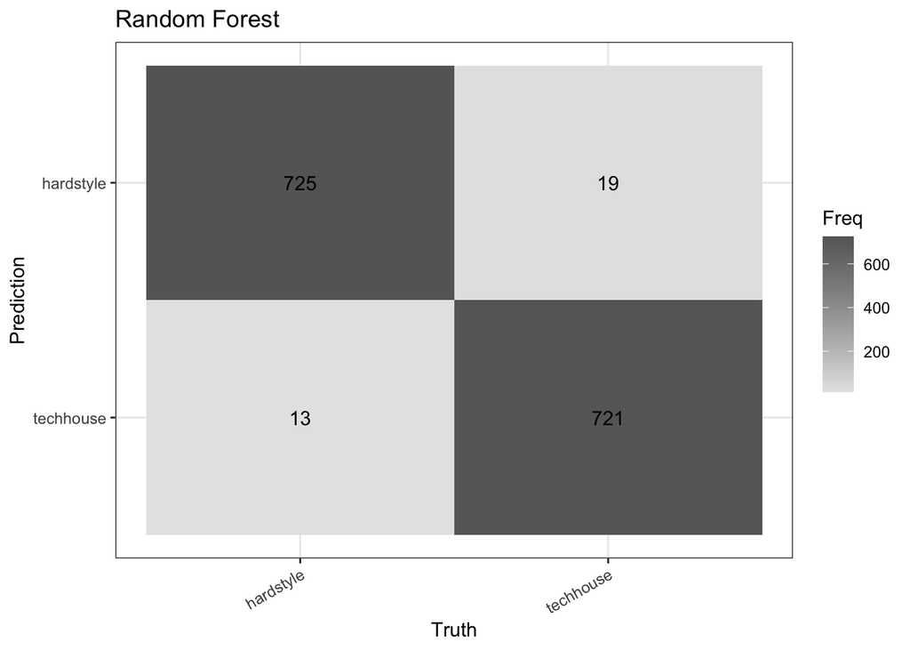

```r
#~~~~~~~~~~~~~~~~~~~~~~~~~~~~~~~~~~~~~~~~~~~~~~~~~~~~~~~~~~~~~~~~~~~~~~~~~~~~~~~
# ----                       Tuning Random Forest                           ----
#~~~~~~~~~~~~~~~~~~~~~~~~~~~~~~~~~~~~~~~~~~~~~~~~~~~~~~~~~~~~~~~~~~~~~~~~~~~~~~~
# ensemble of decision trees
# mtry subsets at each parameter to create tree (must be n-1 no. predictors)
# trees is no. of tree models
rf_model <- rand_forest(mtry = tune(),
                        trees = tune()) %>%
  # this is a package loaded in libs
  set_engine('ranger') %>%
  set_mode('classification')

#~~~~~~~~~~~~~~~~~~~~~~~~~~~~~~~~~~~~~~~~~~~~~~~~~~~~~~~~~~~~~~~~~~~~~~~~~~~~~~~
# ----                           Workflow                                   ----
#~~~~~~~~~~~~~~~~~~~~~~~~~~~~~~~~~~~~~~~~~~~~~~~~~~~~~~~~~~~~~~~~~~~~~~~~~~~~~~~
# establish wkflw for model
rf_workflow <- workflow() %>%
  add_model(rf_model) %>%
  add_recipe(genre_rec)


#~~~~~~~~~~~~~~~~~~~~~~~~~~~~~~~~~~~~~~~~~~~~~~~~~~~~~~~~~~~~~~~~~~~~~~~~~~~~~~~
# ----                        Cross Validation                              ----
#~~~~~~~~~~~~~~~~~~~~~~~~~~~~~~~~~~~~~~~~~~~~~~~~~~~~~~~~~~~~~~~~~~~~~~~~~~~~~~~
# use cross validation to tune mtry and treesfor 5 parameters combinations
# this takes a very long time to run
rf_cv_tune = rf_workflow %>%
  tune_grid(resamples = genre_cv,
            grid = 5)

#~~~~~~~~~~~~~~~~~~~~~~~~~~~~~~~~~~~~~~~~~~~~~~~~~~~~~~~~~~~~~~~~~~~~~~~~~~~~~~~
# ----                         Finalize Workflow                            ----
#~~~~~~~~~~~~~~~~~~~~~~~~~~~~~~~~~~~~~~~~~~~~~~~~~~~~~~~~~~~~~~~~~~~~~~~~~~~~~~~
# store the best tuning metrics
rf_best <- show_best(rf_cv_tune, n = 1, metric = "roc_auc")

# finalize workflow
rf_final <-  finalize_workflow(rf_workflow,
                               rf_best)

#~~~~~~~~~~~~~~~~~~~~~~~~~~~~~~~~~~~~~~~~~~~~~~~~~~~~~~~~~~~~~~~~~~~~~~~~~~~~~~~
# ----                             Fit Model                                ----
#~~~~~~~~~~~~~~~~~~~~~~~~~~~~~~~~~~~~~~~~~~~~~~~~~~~~~~~~~~~~~~~~~~~~~~~~~~~~~~~
# similar functions here.

# fit the KNN model to the training set
train_fit_rf <- fit(rf_final, genre_train)

# get prediction for test
test_predict_rf = predict(train_fit_rf, genre_test) %>%
  # bind to testing column
  bind_cols(genre_test) %>%
  mutate(genre = as.factor(genre))

# get testing prediction probabilities
test_predict2_rf = predict(train_fit_rf,
                           genre_test,
                           type = "prob") %>%
  # bind to testing column
  bind_cols(genre_test) %>%
  mutate(genre = as.factor(genre))

#~~~~~~~~~~~~~~~~~~~~~~~~~~~~~~~~~~~~~~~~~~~~~~~~~~~~~~~~~~~~~~~~~~~~~~~~~~~~~~~
# ----                          Evaluate Model                              ----
#~~~~~~~~~~~~~~~~~~~~~~~~~~~~~~~~~~~~~~~~~~~~~~~~~~~~~~~~~~~~~~~~~~~~~~~~~~~~~~~
# get accuracy of testing prediction
rf_accuracy <- accuracy(test_predict_rf, truth = genre, estimate = .pred_class)

test_predict_rf_num <- as.numeric(test_predict_rf$genre) %>%
  as.numeric(test_predict_rf$.pred_class)

#rf_roc <- roc_curve(test_predict_rf_num,
 #                   genre,
  #                  .pred_class)
#rf_accuracy
#~~~~~~~~~~~~~~~~~~~~~~~~~~~~~~~~~~~~~~~~~~~~~~~~~~~~~~~~~~~~~~~~~~~~~~~~~~~~~~~
# ----                        Visual of Fit Model                          ----
#~~~~~~~~~~~~~~~~~~~~~~~~~~~~~~~~~~~~~~~~~~~~~~~~~~~~~~~~~~~~~~~~~~~~~~~~~~~~~~~
# visualize model

# create confusion matrix
rf_cm <- test_predict_rf %>%
  conf_mat(truth = genre,
           estimate = .pred_class) %>%
  # plot confusion matrix with heatmap
  autoplot(type = "heatmap") +
  # change theme
  theme_bw() +
  theme(axis.text.x = element_text(angle = 30,
                                   hjust=1)) +
  #rotate axis labels
  labs(title = "Random Forest")

rf_cm
```

# Comparing Model Accuracies

When comparing the accuracy of the four models, the Random Forest ML Model produced the highest accuracy of 725 hardstyle (hs) : 721 techhnouse (th) predictions properly assigned, as seen in the visual below. Bagged Trees is the second most accurate with 724 hs : 721 th. Decision tree is next will accuracy of 722 hs : 714 th. The least accurate in its predictions is the KNN model with 713 hs : 711 th properly assigned predictions.

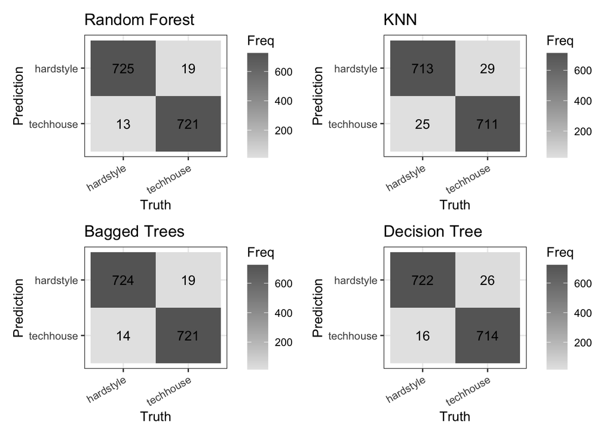

```r
 m1 = test_predict_rf %>%
  conf_mat(truth = genre, estimate = .pred_class) %>% #create confusion matrix
  autoplot(type = "heatmap") + #plot confusion matrix with heatmap
  theme_bw() + #change theme
  theme(axis.text.x = element_text(angle = 30, hjust=1)) +
  #rotate axis labels
  labs(title = "Random Forest")

 m2 = test_predict_knn %>%
  conf_mat(truth = genre, estimate = .pred_class) %>% #create confusion matrix
  autoplot(type = "heatmap") + #plot confusion matrix with heatmap
  theme_bw() + #change theme
  theme(axis.text.x = element_text(angle = 30, hjust=1)) +
  #rotate axis labels
  labs(title = "KNN")

 m3 =  test_predict_bagged %>%
  conf_mat(truth = genre, estimate = .pred_class) %>% #create confusion matrix
  autoplot(type = "heatmap") + #plot confusion matrix with heatmap
  theme_bw() + #change theme
  theme(axis.text.x = element_text(angle = 30, hjust=1)) +
  #rotate axis labels
  labs(title = "Bagged Trees")

 m4 =  test_predict_tree %>%
  conf_mat(truth = genre, estimate = .pred_class) %>% #create confusion matrix
  autoplot(type = "heatmap") + #plot confusion matrix with heatmap
  theme_bw() + #change theme
  theme(axis.text.x = element_text(angle = 30, hjust=1)) +
  #rotate axis labels
  labs(title = "Decision Tree")


m1 + m2 + m3 + m4
```